# jj vignette

Overview of applications of the different functions in the jj package.

# Tutorial

In this tutorial, we will use the pbmc_small example object provided together with the Seurat package.

The function **j** can be used to get a quick overview on any R object.

```r
j(pbmc_small)
```

```
## An object of class Seurat
## 230 features across 80 samples within 1 assay
## Active assay: RNA (230 features, 20 variable features)
##  2 dimensional reductions calculated: pca, tsne
```

```r
j(pbmc_small@meta.data)
```

```
## data.frame with 80 rows and 7 columns
```

|  | orig.ident | nCount_RNA | nFeature_RNA |
| --- | --- | --- | --- |
| ATGCCAGAACGACT | SeuratProject | 70 | 47 |
| CATGGCCTGTGCAT | SeuratProject | 85 | 52 |
| GAACCTGATGAACC | SeuratProject | 87 | 50 |

```r
j(GetAssayData(pbmc_small))
```

```
## dgCMatrix with 230 rows and 80 columns
```

```
## 3 x 3 sparse Matrix of class "dgCMatrix"
##       ATGCCAGAACGACT CATGGCCTGTGCAT GAACCTGATGAACC
## MS4A1       .                     .              .
## CD79B       4.968821              .              .
## CD79A       .                     .              .
```

## jj_plot_features

### Overview

**jj_plot_features** is the core function from the jj package and includes many plotting options. We can get a first impression of the dataset by ploting a dimensionality reduction without colouring by any feature:

```
## Validating object
```

```
## Getting features from meta.data
```

```
## Continous or discrete feature order: d
```

```
## plotting features
```

```
## 1/1: data
```

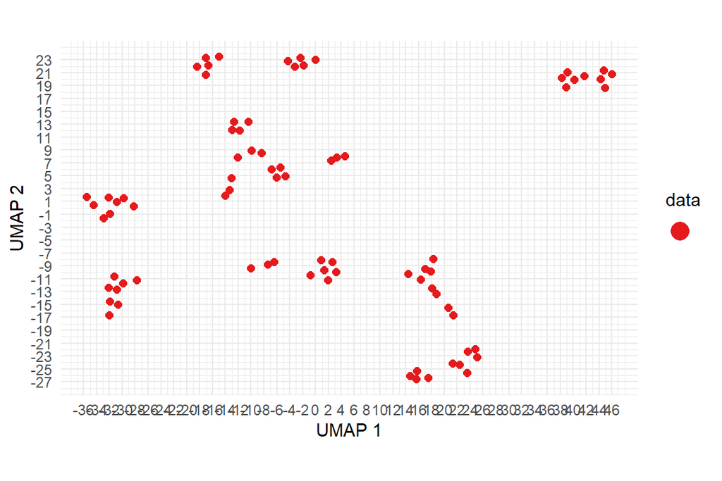

```r
jj_plot_features(pbmc_small, reduction = 'tsne')
```

### Colour by meta.data

```
## Validating object
```

```
## Getting features from meta.data
```

```
## Continous or discrete feature order: d
```

```
## plotting features
```

```
## 1/1: letter.idents
```

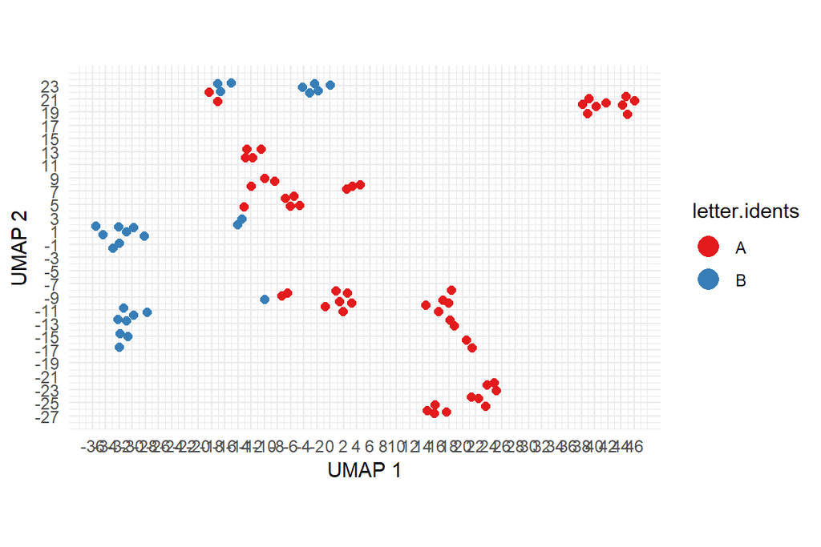

```r
jj_plot_features(pbmc_small, reduction = 'tsne', features = 'letter.idents')
```

### Colour by features

```
## Validating object
```

```
## Getting features from data slot of the RNA assay in the Seurat object
```

```
##
##
## Expression values found for all 2 features
```

```
## Capping meta feature values
```

```
## cap_top: not capped
```

```
## cap_top: 0.95
```

```
## plotting features
```

```
## 1/2: CD19
```

```
## 2/2: CD8A
```

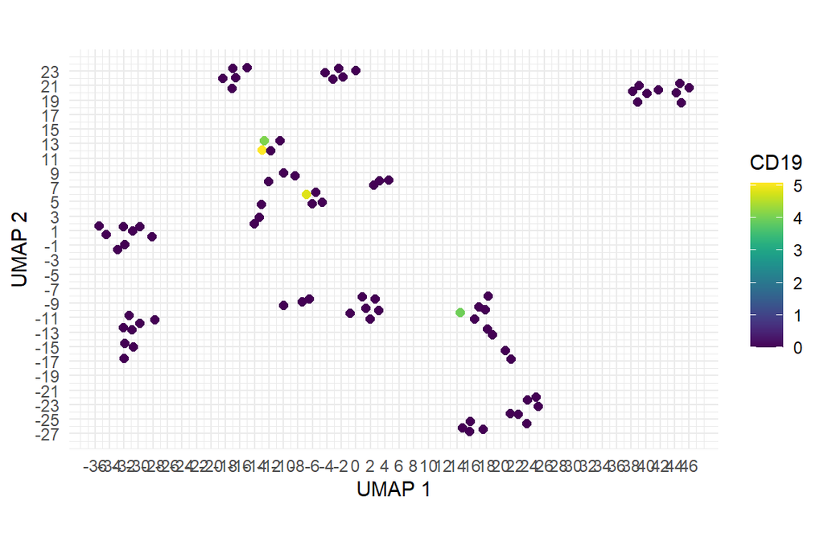

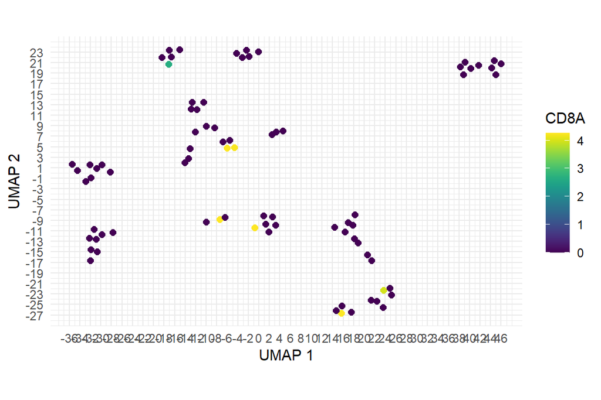

```r
jj_plot_features(pbmc_small, reduction = 'tsne', features = c('CD19', 'CD8A'), cap_top = 'auto')
```

### Use facets

We can specify a column from the (meta.data) data.frame to facet the plot:

```
## Validating object
```

```
## Getting features from meta.data
```

```
## Continous or discrete feature order: d
```

```
## plotting features
```

```
## 1/1: letter.idents
```

```
## Facetting by groups.
```

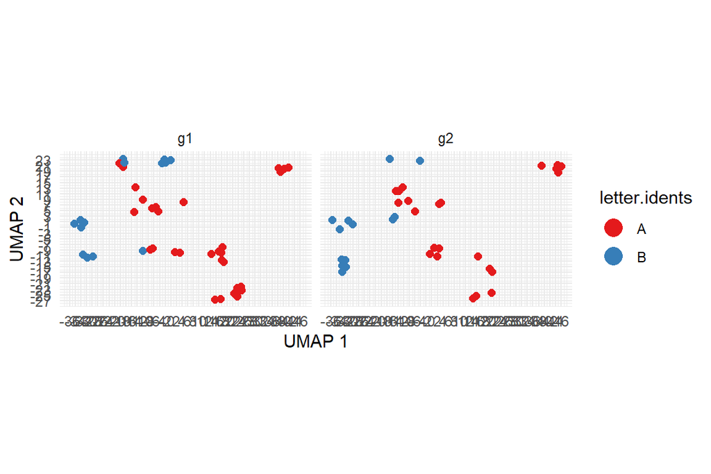

```r
jj_plot_features(pbmc_small, reduction = 'tsne', features = 'letter.idents', facet_by = 'groups')
```

### Show background cells

Optionally, points not part of the facet can be shown in grey as background. It is also possible to only show selected facets by specifying facet_subset.

```
## Validating object
```

```
## Getting features from meta.data
```

```
## Continous or discrete feature order: d
```

```
## plotting features
```

```
## 1/1: letter.idents
```

```
## Facetting by groups.
```

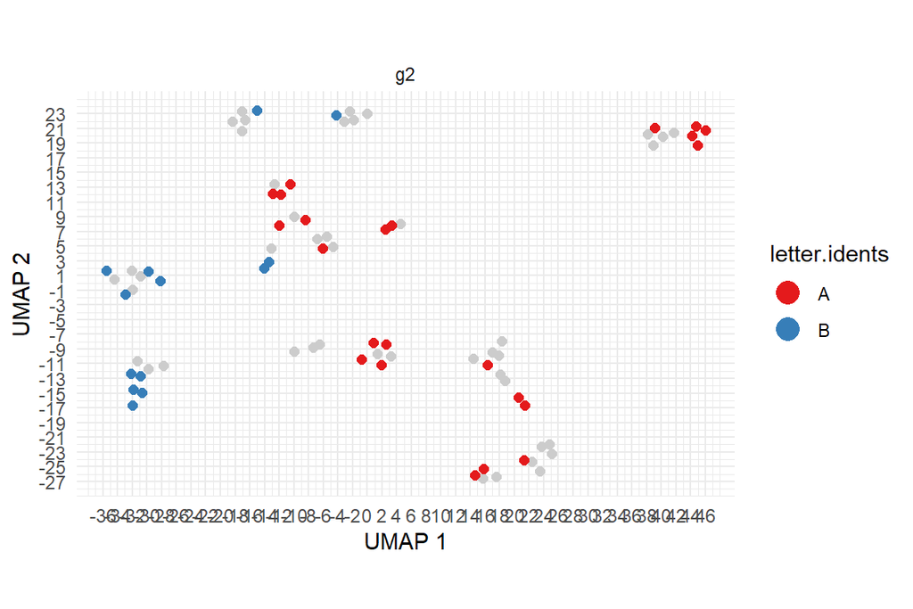

```r
jj_plot_features(pbmc_small, reduction = 'tsne', features = 'letter.idents', facet_by = 'groups', show_background_cells = T, facet_subset = 'g2')
```

### Density

Instead of colouring by a feature, the number of neighbours for each point can be shown

```
## Validating object
```

```
## Getting features from meta.data
```

```
## Continous or discrete feature order: d
```

```
## plotting features
```

```
## 1/1: data
```

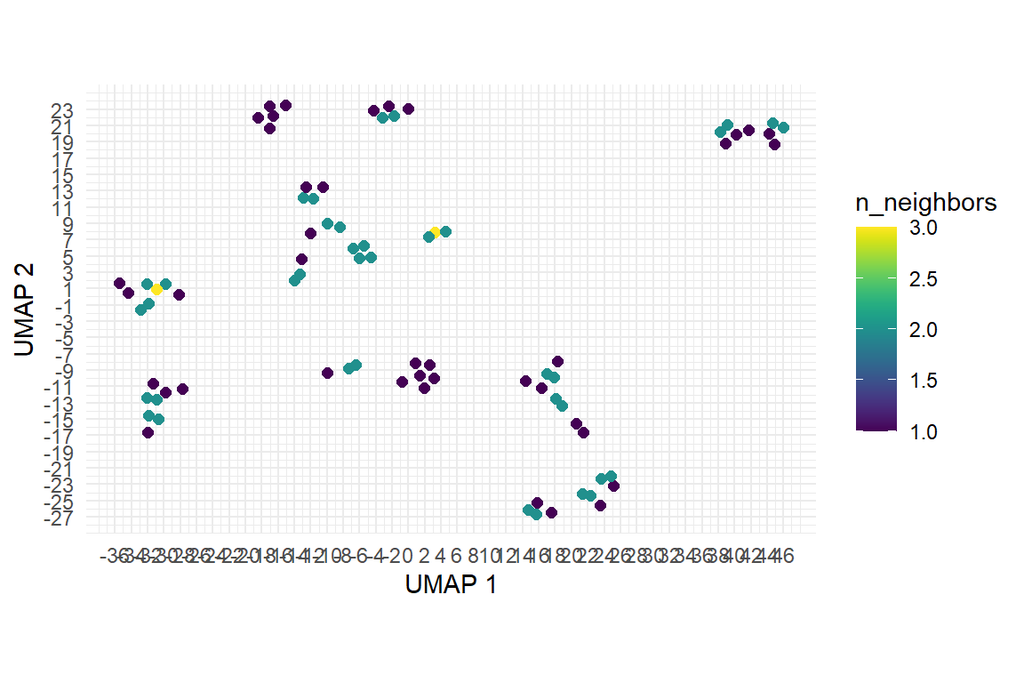

```r
jj_plot_features(pbmc_small, reduction = 'tsne', use_pointdensity = T)
```

### Define custom background cells

The parameter foreground_subset_bool takes a logical vector of the same length as observations in the object that defines, which cells are seen as background. Background cells are excluded for the neigbhour calculation.

```
## Validating object
```

```
## Getting features from meta.data
```

```
## Continous or discrete feature order: d
```

```
## plotting features
```

```
## 1/1: data
```

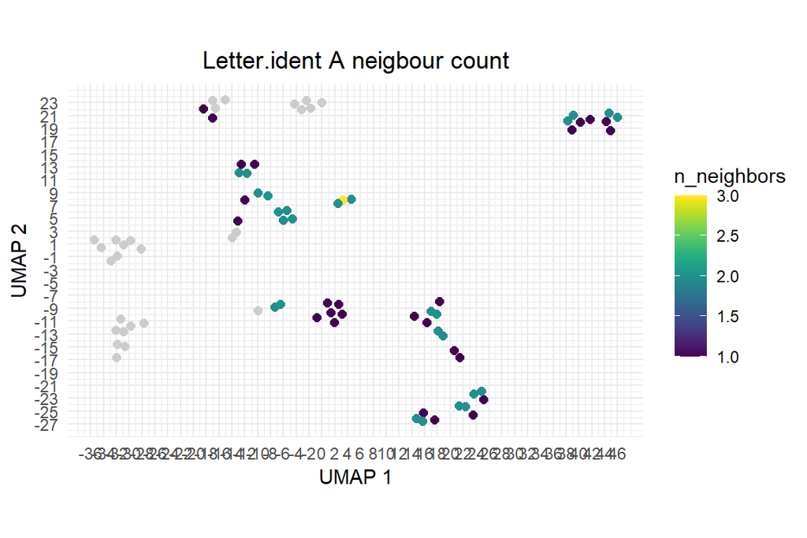

```r
jj_plot_features(pbmc_small, reduction = 'tsne', use_pointdensity = T, foreground_subset_bool = pbmc_small$letter.idents == 'A', show_background_cells = T, my_title = 'Letter.ident A neigbour count')
```

### Add labels

At the mean position for each subgroup, we can add a label for an easier identification in the plot

```
## Validating object
```

```
## Getting features from meta.data
```

```
## Continous or discrete feature order: d
```

```
## plotting features
```

```
## 1/1: RNA_snn_res.1
```

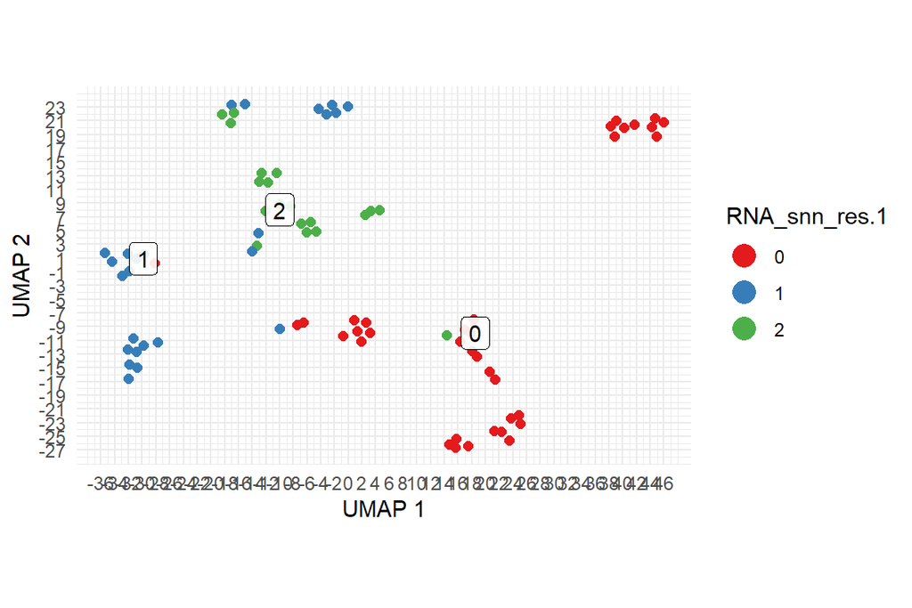

```r
jj_plot_features(pbmc_small, reduction = 'tsne', features = 'RNA_snn_res.1', label_type = 'geom_label', fill_colors = 'white')
```

### Show area capturing density

Instead of colouring by a categorical feature, its density can be plotted as areas allowing the specification of another feature in the plot.

```
## Validating object
```

```
## Getting features from meta.data
```

```
## Continous or discrete feature order: c
```

```
## plotting features
```

```
## 1/1: nCount_RNA
```

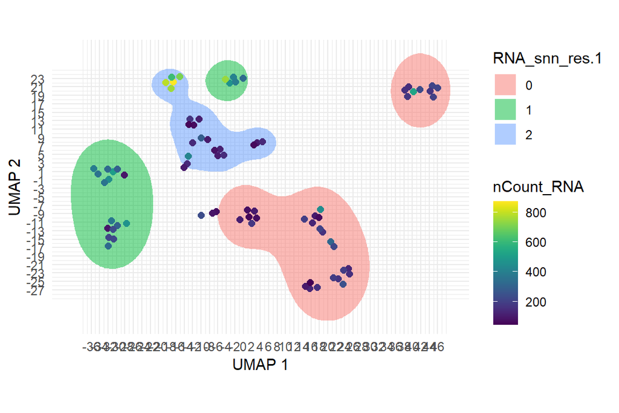

```r
jj_plot_features(pbmc_small, reduction = 'tsne', features = 'nCount_RNA', area_by = 'RNA_snn_res.1', )
```

### Change colours and graphical parameters

Many graphical parameters can be easily adapted.

```
## Validating object
```

```
## Getting features from meta.data
```

```
## Continous or discrete feature order: d
```

```
## plotting features
```

```
## 1/1: RNA_snn_res.1
```

```
## Using colors provided unter custom_colors.
```

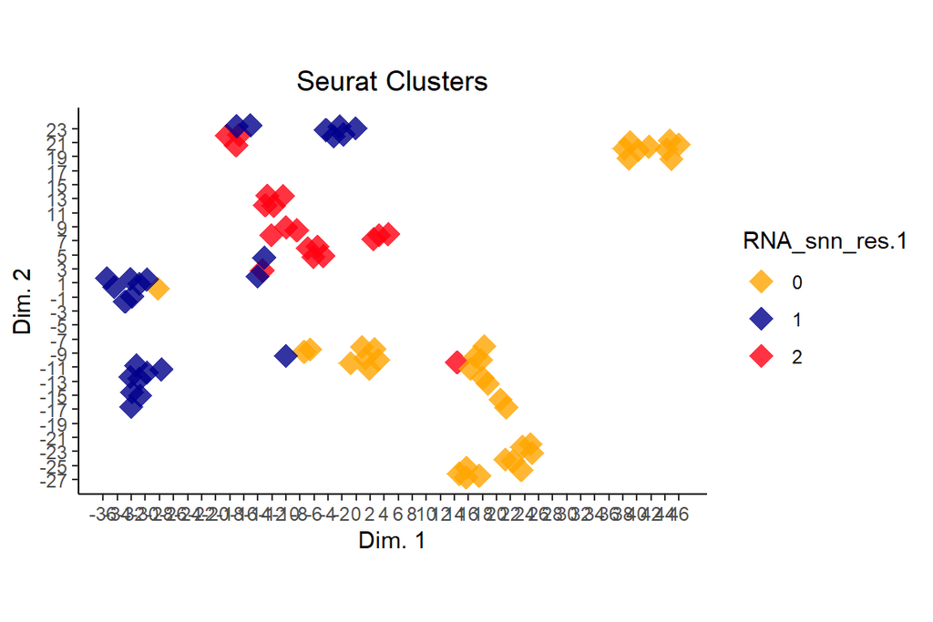

```r
jj_plot_features(pbmc_small, reduction = 'tsne', features = 'RNA_snn_res.1', custom_colors = c('0' = 'orange', '1' = 'darkblue', '2' = "#FF0011"), pt_size = 5, custom_theme = theme_classic(), my_title = 'Seurat Clusters', xlabel = 'Dim. 1', ylabel = 'Dim. 2', shape = 18, alpha = 0.8)
```

### Change point order and cap values

Instead of shuffeling the points (default), points can be ordered by their value as well. Also, the range for continuous variables can be capped at the top or bottom by specifying a threshold, a quantile, or ‘auto’ to determine a useful threshold automatically.

```
## Validating object
```

```
## Getting features from meta.data
```

```
## Continous or discrete feature order: c
```

```
## Capping meta feature values
```

```
## plotting features
```

```
## 1/1: nCount_RNA
```

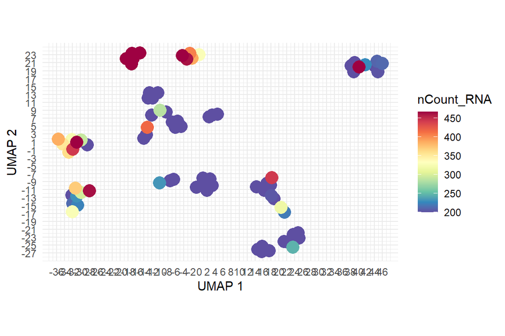

```r
jj_plot_features(pbmc_small, reduction = 'tsne', features = 'nCount_RNA', color_scale = 'spectral', pt_size = 5, order_type = 'order', cap_top = 'q90', cap_bottom = 200)
```

### modify gg plot and arrange in a grid

When return_gg_object = T, ggplot objects are returned as a list that can be modified. Multiple plots can be arranged in a grid using jj_arrange_ggplots()

```r
gg_list = jj_plot_features(pbmc_small, reduction = 'tsne', features = c('letter.idents', 'nCount_RNA', 'RNA_snn_res.1'), return_gg_object = T)
```

```
## Validating object
```

```
## Getting features from meta.data
```

```
## Continous or discrete feature order: dcd
```

```
## plotting features
```

```
## 1/3: letter.idents
```

```
## 2/3: nCount_RNA
```

```
## 3/3: RNA_snn_res.1
```

```r
gg_list[[2]] = gg_list[[2]] + theme_dark() + scale_colour_gradient2()
```

```
## which will replace the existing scale.
```

```
## $`1`
```

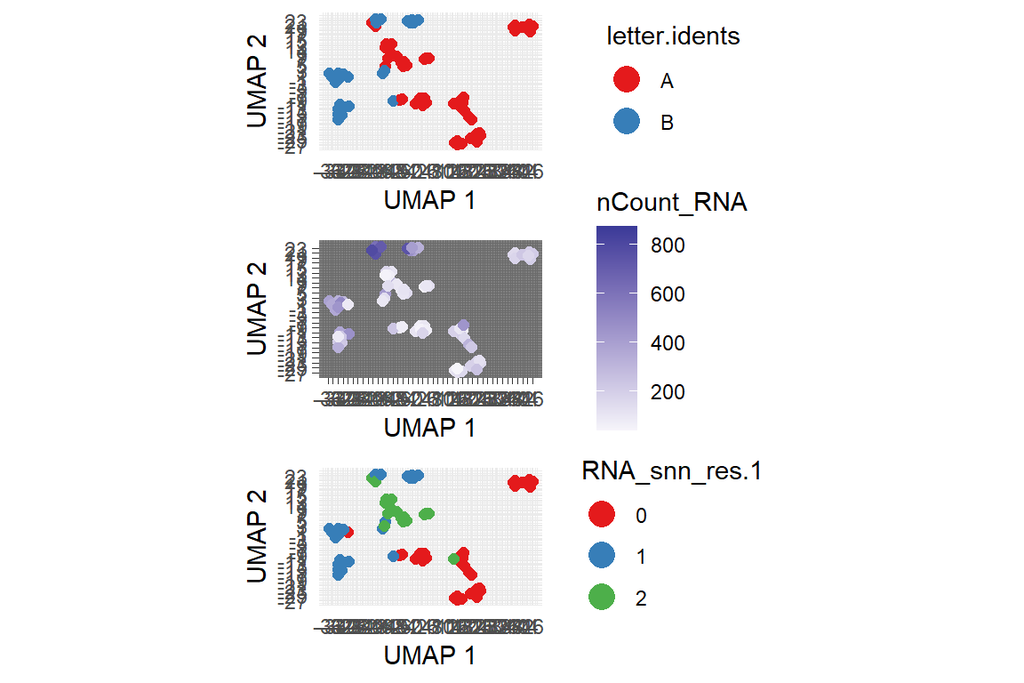

```r
jj_arrange_ggplots(gg_list, nplots =3, cols = 1)
```

## Violin / boxplots

### jj_plot_categorical_by_group

Calculate the fractions of a categorical variable by another group variable

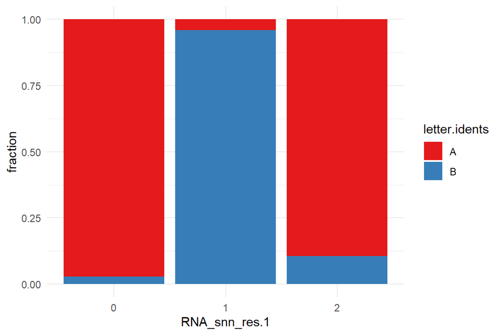

```r
jj_plot_categorical_by_group(pbmc_small@meta.data, feature_column = 'letter.idents', group_column = 'RNA_snn_res.1')
```

Or plot absolute counts and optionally add text. The coordinates can be swapped if needed.

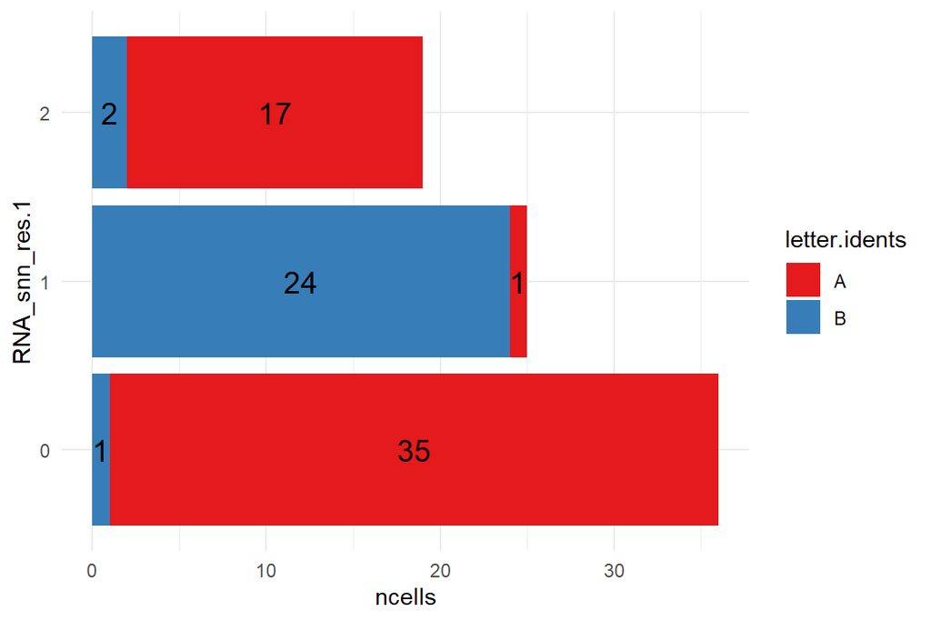

```r
jj_plot_categorical_by_group(pbmc_small@meta.data, feature_column = 'letter.idents', group_column = 'RNA_snn_res.1', absolute_numbers = T, add_text = T, flip_coordinates = T)
```

### jj_plot_numeric_by_group

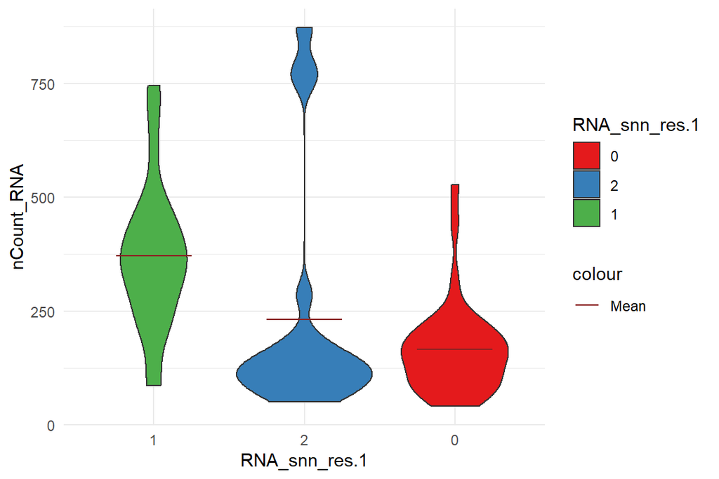

```r
jj_plot_numeric_by_group(pbmc_small@meta.data, feature_column = 'nCount_RNA', group_column = 'RNA_snn_res.1', order = T)
```

### jj_plot_sparse_by_group

Useful to plot sparse features. Can additionally show the fraction of cells expressing the feature as piechart below the groups.

```
##
##
## Expression values found for all 1 features
```

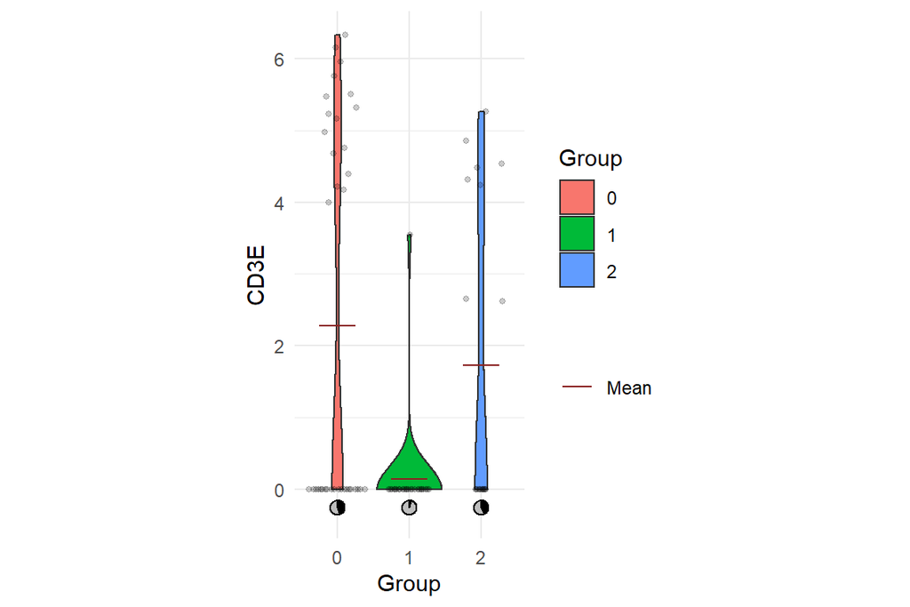

```r
jj_plot_sparse_by_group_seurat(pbmc_small, gene_plot = 'CD3E', group_column = 'RNA_snn_res.1', plot_cell_sample = T)
```

## Heatmap / Dotplot

### jj_plot_heatmap

[output not shown]

```
##
##
## Expression values found for all 5 features
```

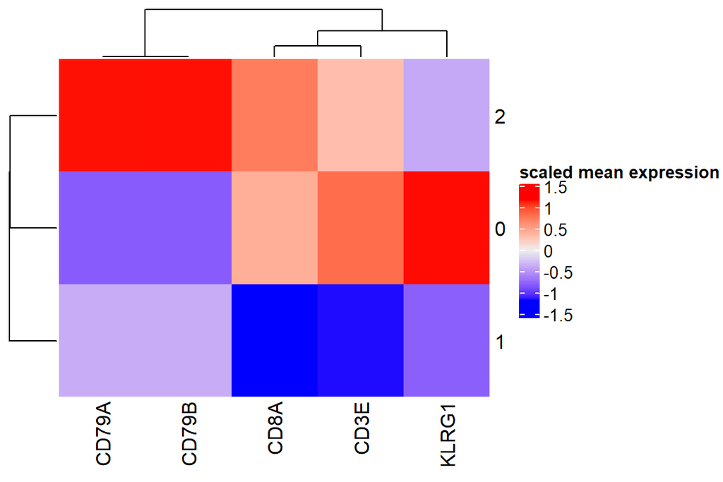

```r
jj_plot_heatmap(pbmc_small, features_use = c('CD8A','KLRG1','CD79A','CD79B','CD3E'), group_vec = pbmc_small$RNA_snn_res.1)
```

### jj_plot_dotplot

```
## Class of obj is Seurat, using the DefaultAssay: RNA
```

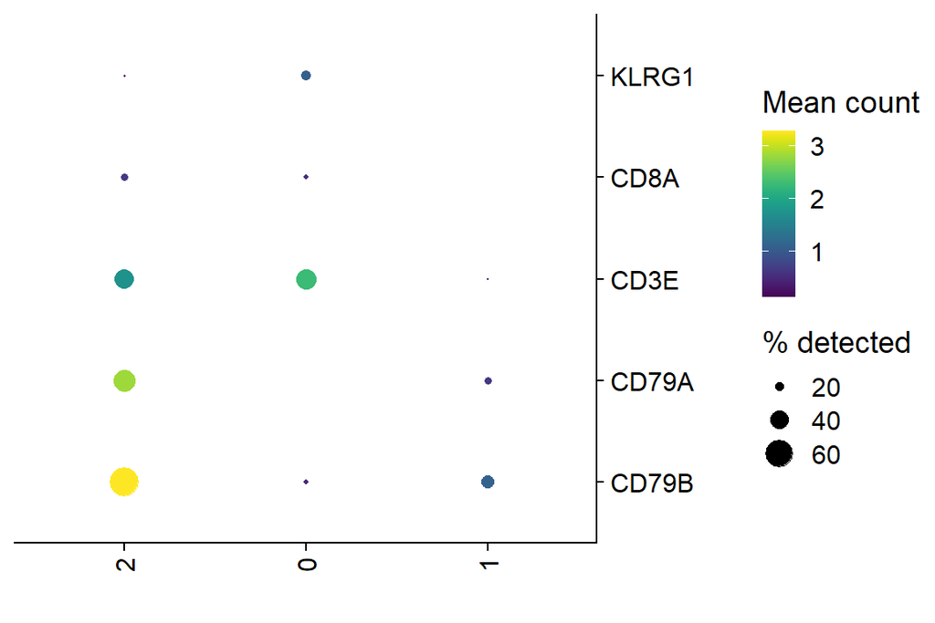

```r
jj_plot_dotplot(pbmc_small, features_use = c('CD8A','KLRG1','CD79A','CD79B','CD3E'), group_vec = pbmc_small$RNA_snn_res.1)
```

## Histogram

### coloured by threshold

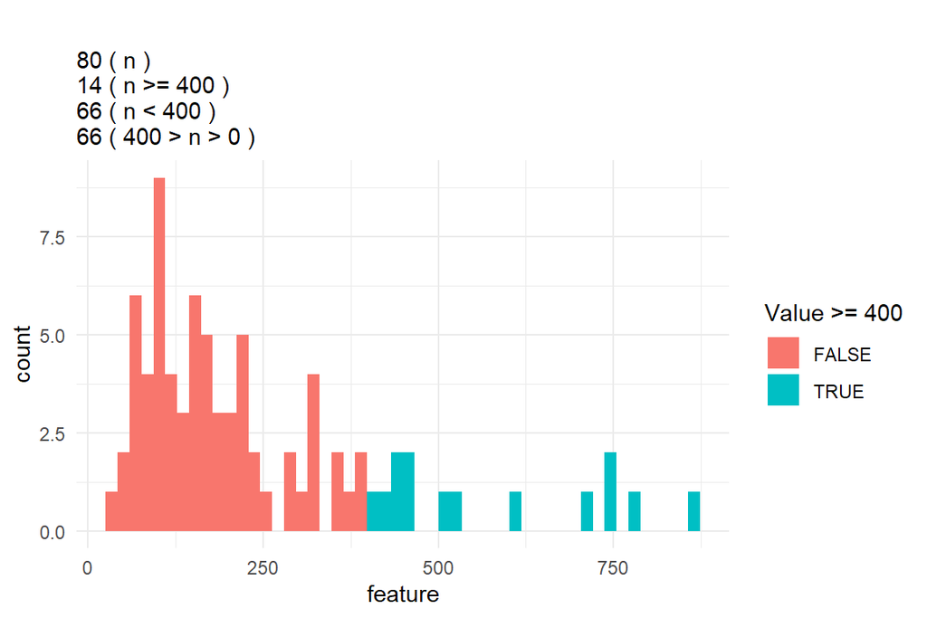

```r
jj_plot_hist(pbmc_small$nCount_RNA, thres = 400)
```

### coloured by categorical feature and split by group

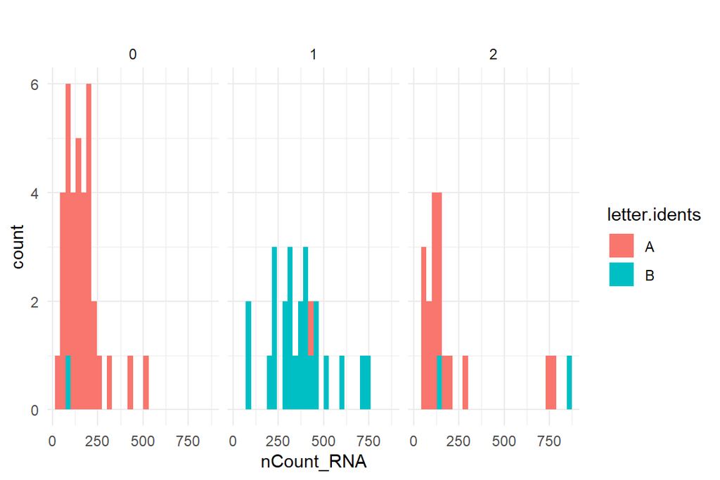

```r
jj_plot_hist(pbmc_small@meta.data, feature = 'nCount_RNA', group = 'RNA_snn_res.1', fill = 'letter.idents', nbins = 30)
```

### coloured by categorical feature and with border colours

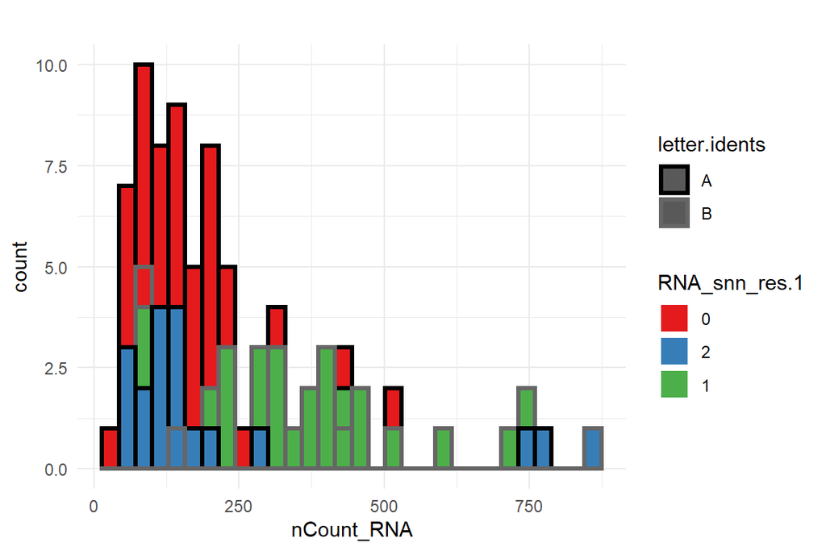

```r
jj_plot_hist(pbmc_small@meta.data, feature = 'nCount_RNA', colour = 'letter.idents', fill = 'RNA_snn_res.1', nbins = 30, size = 1.2) +
  scale_colour_manual(values =  c('A'='black','B'='grey40')) + scale_fill_manual(values = jj_get_jj_colours(pbmc_small$RNA_snn_res.1))
```

## Volcano / Fold-change plot

Use Seurat to find marker genes separating different clusters.

```r
marker_df = FindMarkers(pbmc_small, group.by = 'RNA_snn_res.1', ident.1 = '0', ident.2 = '1', verbose = F)
marker_df$symbol = rownames(marker_df)
print(head(marker_df))
```

```
##                 p_val avg_log2FC pct.1 pct.2    p_val_adj   symbol
## TYMP     1.702818e-11  -3.663419 0.111  1.00 3.916481e-09     TYMP
## CST3     4.469249e-11  -3.682867 0.306  1.00 1.027927e-08     CST3
## S100A8   5.334985e-11  -5.824228 0.111  0.96 1.227047e-08   S100A8
## LYZ      6.997602e-11  -4.446603 0.417  1.00 1.609449e-08      LYZ
## HLA-DRB1 3.287672e-10  -4.797148 0.083  0.88 7.561646e-08 HLA-DRB1
## HLA-DPB1 4.061018e-10  -5.117840 0.083  0.88 9.340340e-08 HLA-DPB1
```

```r
marker_df2 = FindMarkers(pbmc_small, group.by = 'RNA_snn_res.1', ident.1 = '0', ident.2 = '2', verbose = F)
marker_df2$symbol = rownames(marker_df2)

markers_joined = dplyr::inner_join(marker_df, marker_df2, by = 'symbol', suffix = c('.0_vs_1', '.0_vs_2'))
head(markers_joined)
```

|  | p_val.0_vs_1 | avg_log2FC.0_vs_1 | pct.1.0_vs_1 | pct.2.0_vs_1 | p_val_adj.0_vs_1 | symbol | p_val.0_vs_2 | avg_log2FC.0_vs_2 | pct.1.0_vs_2 | pct.2.0_vs_2 | p_val_adj.0_vs_2 |
| --- | --- | --- | --- | --- | --- | --- | --- | --- | --- | --- | --- |
| 1 | 1.702818e-11 | -3.663419 | 0.111 | 1.00 | 3.916481e-09 | TYMP | 1.653086e-01 | -1.087286 | 0.111 | 0.263 | 1.000000e+00 |
| 2 | 4.469249e-11 | -3.682867 | 0.306 | 1.00 | 1.027927e-08 | CST3 | 3.134548e-01 | -2.408090 | 0.306 | 0.368 | 1.000000e+00 |
| 3 | 5.334985e-11 | -5.824228 | 0.111 | 0.96 | 1.227047e-08 | S100A8 | 4.454509e-01 | 1.895238 | 0.111 | 0.053 | 1.000000e+00 |
| 4 | 6.997602e-11 | -4.446603 | 0.417 | 1.00 | 1.609449e-08 | LYZ | 3.425637e-02 | -2.537471 | 0.417 | 0.579 | 1.000000e+00 |
| 5 | 3.287672e-10 | -4.797148 | 0.083 | 0.88 | 7.561646e-08 | HLA-DRB1 | 3.538045e-09 | -5.976681 | 0.083 | 0.842 | 8.137504e-07 |
| 6 | 4.061018e-10 | -5.117840 | 0.083 | 0.88 | 9.340340e-08 | HLA-DPB1 | 9.146505e-11 | -6.412990 | 0.083 | 0.947 | 2.103696e-08 |

### Volcano plot with marker threshold

Specify the fold-change, p-value and gene symbol columns to plot a volcano plot. Optionally, text can be printed for markers above/below a threshold. The labs_range argument defines the axis range that is plotted.

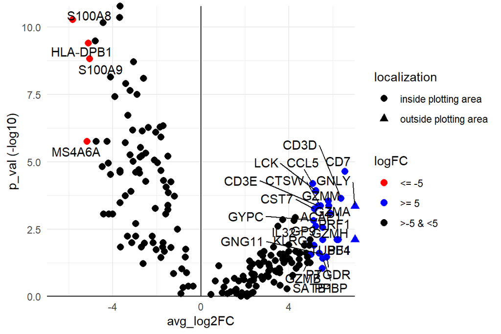

```r
jj_plot_volcano(marker_df, logfc_column = 'avg_log2FC', pval_column = 'p_val', symbol_column = 'symbol', use_text = T, labs_range = c(-7,7), marker_thres = 5)
```

### Custom highlights

Instead of highlighting everything above/below a threshold, specific markers can be highlighted.

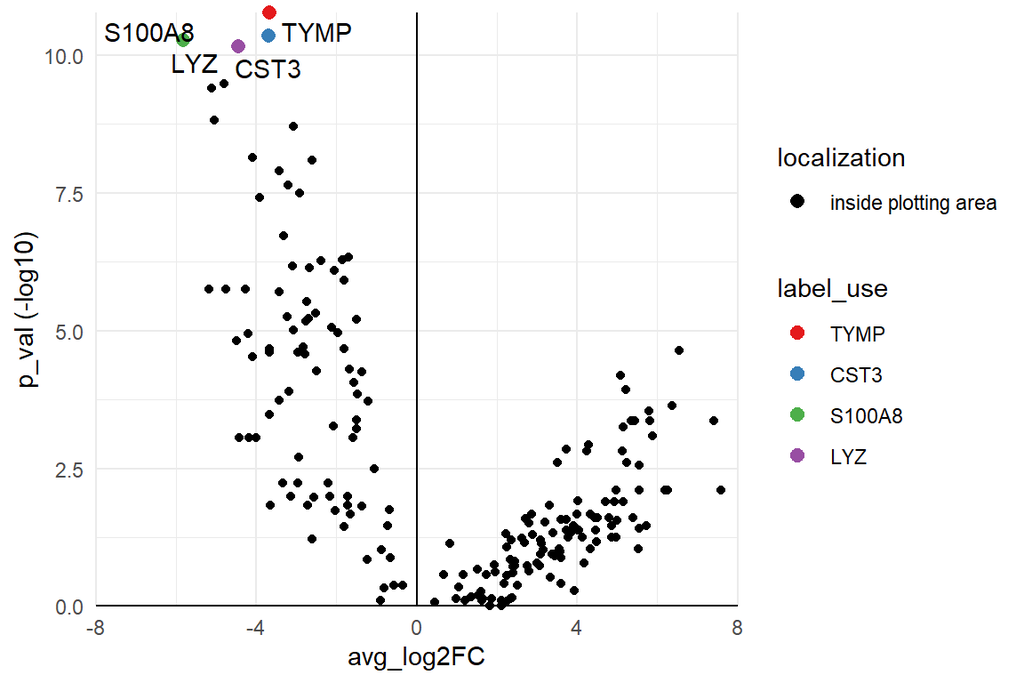

```r
jj_plot_volcano(marker_df, logfc_column = 'avg_log2FC', pval_column = 'p_val', symbol_column = 'symbol',
               labs_range = c(-8, 8),  markers_highlight = marker_df$symbol[1:4], pt.size = 1.5, marker_thres = Inf,
               only_highlight = F, col_by_highlight = T)
```

### Fold-change vs fold-change

Compare the fold-changes from two comparisons against each other with jj_plot_fc_fc.

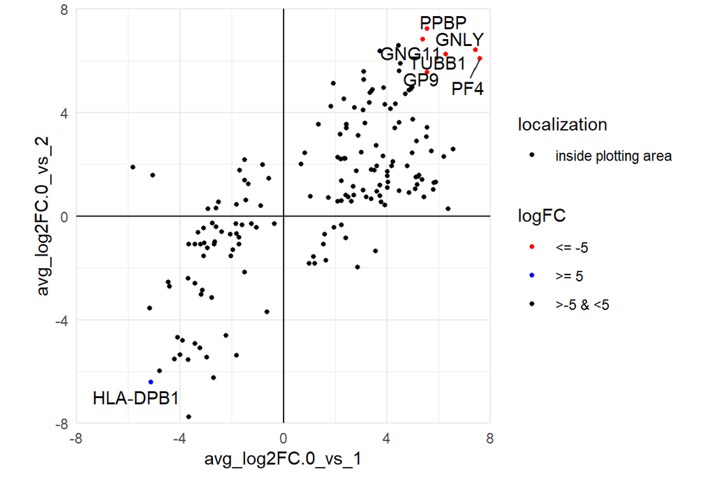

```r
jj_plot_fc_fc(markers_joined, logfc_column1 = 'avg_log2FC.0_vs_1', logfc_column2 = 'avg_log2FC.0_vs_2',symbol_column = 'symbol', labs_range = c(-8,8, -8,8), marker_thres = 5, use_text = T)
```